# Users versus trips: a matched-snapshot experiment

# What this comparison can show

We start with one fixed sample of people and their linked trips. For each mode, we construct a counterfactual by switching existing short car trips. We then ask HUB to reconstruct that scenario from either its user counts or its trip counts. Neither reconstruction is supplied with the other route’s count target.

Differences **between repeated seeds** measure sampling variation conditional on this fixed population. Persistent differences **between routes** can reflect different completion/allocation assumptions, missing information, or defects; they are not automatically bugs. Equal total MMET does not imply equal health benefits if different people receive the activity.

| Population | Seeds | Successful | Failed |
| --- | --- | --- | --- |
| 500 | 2 | 112 | 0 |

# Design and boundaries

- All modes: walking, cycling, e-biking, and PT access walking.
- Two benchmarks: new users (previously no AT in any mode), and extra trips among current users of the target mode. Up to five eligible people receive up to two switched trips each. Donor journeys are positive-distance, at most 5 km, and utilitarian. The benchmark does not add rows or induce trips.
- Fixed population identities, no geographic population multiplier, 40 model years and immediate full effect for every route.
- **Defaults:** normal completion assumptions, except shared zero induction and car-only diversion. **Benchmark-informed:** trip frequency and distance are derived from the actual switched trips; new-user preference is 100% or 0% according to scenario. These settings still do not encode recipient identities.
- **Basic:** direct final-results API. **Advanced:** Tab 2 population staging followed by acceptance of the generated Tab 3 tables and Tab 4 staging. Both now use `Hub$build_results()` with canonical persisted assumptions. This is not a browser test. Earlier rendered results must be regenerated after this workflow change before interpreting them as current.
- Seeds are shared across routes for convenience; identical seeds do not guarantee identical people are sampled. Source selection uses a separate, fixed seed. This pilot does not measure uncertainty in the source sample or HM.

An existing-users benchmark can have identical REF/CF user counts but additional trips. The users-only route cannot convey that increase. A zero result on that route is an expected information limitation, not evidence of sampling failure. Native e-bike current-user scenarios are unavailable if the sample has no e-bikers.

The benchmark’s new users have no prior AT in any mode. Explicit user-count requests, however, can recruit people who already use another AT mode; they override the new-user percentage. Consequently, even benchmark-informed aggregate assumptions do not guarantee the same recipient pool or dose per person. This is one of the allocation distinctions the experiment is meant to expose, rather than hide by forcing identical recipients into both routes.

## Benchmarks and unavailable cases

| mode | scenario | ref_users | users | ref_trips | trips | trip_minutes | mmet_delta | halys |
| --- | --- | --- | --- | --- | --- | --- | --- | --- |
| walking | new_users | 210 | 215 | 1939 | 1948 | 31054.959 | 13.998 | 2.529 |
| walking | existing_users | 210 | 210 | 1939 | 1949 | 31105.160 | 16.090 | 1.035 |
| cycling | new_users | 18 | 23 | 88 | 97 | 1985.993 | 10.343 | 1.974 |
| cycling | existing_users | 18 | 18 | 88 | 97 | 1990.298 | 10.759 | 0.523 |
| ebiking | new_users | 0 | 5 | 0 | 9 | 89.161 | 8.619 | 1.685 |
| pt | new_users | 33 | 38 | 85 | 94 | 1758.406 | 7.017 | 1.351 |
| pt | existing_users | 33 | 33 | 85 | 94 | 1758.406 | 7.017 | 0.543 |

| mode | scenario | reason |
| --- | --- | --- |
| ebiking | existing_users | No eligible current users/car-trip owners for this benchmark. |

# Health results

## First things to inspect

- Largest matched basic/advanced HALY difference: **1.43**. Both paths include final results reconstruction.
- For extra trips among existing users, the users-only inputs are unchanged. Their zero-change result is expected.
- Compare the two assumption settings before attributing a route difference to randomness. Even matching trip counts need not match person-level activity or baseline risk.
- Walking and PT trips remain distinct. PT walkers qualify as existing walking recipients; their eligibility alone does not add them to separate-walking user counts.

Black horizontal lines show benchmark HALYs. Points are individual seeds; colours distinguish assumption settings. The panels deliberately have separate scales. This refresh uses 2 draws per combination; it is a diagnostic comparison, not a reliable confidence interval.

**WarningPT correctness finding in this refresh**

The two-seed current-code refresh matches basic/advanced results exactly for walking, cycling and e-biking, but not PT. For the PT trips route, Tab 2 targets of 85 REF / 94 CF trips become generated Tab 4 defaults of zero; the final advanced result then contains zero CF PT trips. The largest paired HALY difference is 1.429874. Treat PT results below as diagnostic evidence of this defect, not sampling variation. A targeted replay confirms that staged data contains 85/94 PT access-walking trips, while the materialized REF/CF views contain zero. Shared walking-component columns are cleared during scope materialization. Preserve PT access activity there and add a real-data regression before rerunning.

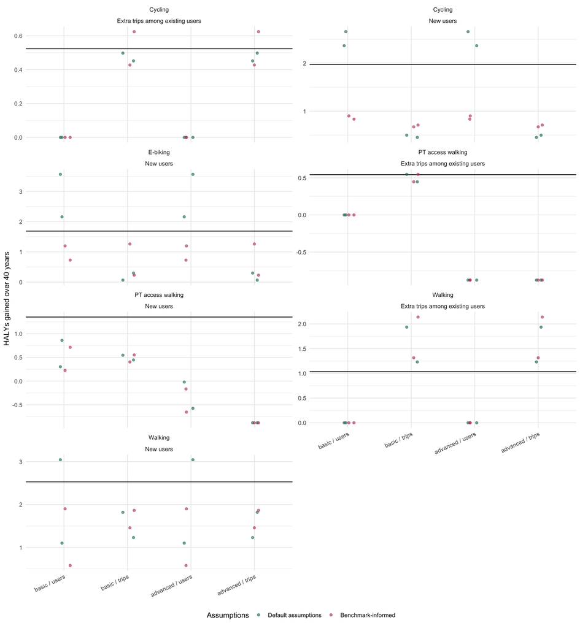

## Route means and variation

| mode | scenario | workflow | route | assumptions | n | mean_halys | sd_halys | mean_difference_from_benchmark | distinct_exposures |
| --- | --- | --- | --- | --- | --- | --- | --- | --- | --- |
| cycling | existing_users | advanced | trips | benchmark_informed | 2 | 0.5258 | 0.1390 | 0.0025 | 2 |
| cycling | existing_users | advanced | trips | defaults | 2 | 0.4746 | 0.0326 | -0.0487 | 2 |
| cycling | existing_users | advanced | users | benchmark_informed | 2 | 0.0000 | 0.0000 | -0.5232 | 1 |
| cycling | existing_users | advanced | users | defaults | 2 | 0.0000 | 0.0000 | -0.5232 | 1 |
| cycling | existing_users | basic | trips | benchmark_informed | 2 | 0.5258 | 0.1390 | 0.0025 | 2 |
| cycling | existing_users | basic | trips | defaults | 2 | 0.4746 | 0.0326 | -0.0487 | 2 |
| cycling | existing_users | basic | users | benchmark_informed | 2 | 0.0000 | 0.0000 | -0.5232 | 1 |
| cycling | existing_users | basic | users | defaults | 2 | 0.0000 | 0.0000 | -0.5232 | 1 |
| cycling | new_users | advanced | trips | benchmark_informed | 2 | 0.6907 | 0.0272 | -1.2834 | 2 |
| cycling | new_users | advanced | trips | defaults | 2 | 0.4746 | 0.0326 | -1.4996 | 2 |
| cycling | new_users | advanced | users | benchmark_informed | 2 | 0.8660 | 0.0472 | -1.1081 | 2 |
| cycling | new_users | advanced | users | defaults | 2 | 2.5123 | 0.2072 | 0.5382 | 2 |
| cycling | new_users | basic | trips | benchmark_informed | 2 | 0.6907 | 0.0272 | -1.2834 | 2 |
| cycling | new_users | basic | trips | defaults | 2 | 0.4746 | 0.0326 | -1.4996 | 2 |
| cycling | new_users | basic | users | benchmark_informed | 2 | 0.8660 | 0.0472 | -1.1081 | 2 |
| cycling | new_users | basic | users | defaults | 2 | 2.5123 | 0.2072 | 0.5382 | 2 |
| ebiking | new_users | advanced | trips | benchmark_informed | 2 | 0.7438 | 0.7290 | -0.9417 | 2 |
| ebiking | new_users | advanced | trips | defaults | 2 | 0.1812 | 0.1648 | -1.5043 | 2 |
| ebiking | new_users | advanced | users | benchmark_informed | 2 | 0.9609 | 0.3315 | -0.7245 | 2 |
| ebiking | new_users | advanced | users | defaults | 2 | 2.8625 | 0.9940 | 1.1770 | 2 |
| ebiking | new_users | basic | trips | benchmark_informed | 2 | 0.7438 | 0.7290 | -0.9417 | 2 |
| ebiking | new_users | basic | trips | defaults | 2 | 0.1812 | 0.1648 | -1.5043 | 2 |
| ebiking | new_users | basic | users | benchmark_informed | 2 | 0.9609 | 0.3315 | -0.7245 | 2 |
| ebiking | new_users | basic | users | defaults | 2 | 2.8625 | 0.9940 | 1.1770 | 2 |
| pt | existing_users | advanced | trips | benchmark_informed | 2 | -0.8780 | 0.0000 | -1.4205 | 1 |
| pt | existing_users | advanced | trips | defaults | 2 | -0.8780 | 0.0000 | -1.4205 | 1 |
| pt | existing_users | advanced | users | benchmark_informed | 2 | -0.8780 | 0.0000 | -1.4205 | 1 |
| pt | existing_users | advanced | users | defaults | 2 | -0.8780 | 0.0000 | -1.4205 | 1 |
| pt | existing_users | basic | trips | benchmark_informed | 2 | 0.4967 | 0.0706 | -0.0458 | 2 |
| pt | existing_users | basic | trips | defaults | 2 | 0.4967 | 0.0706 | -0.0458 | 2 |
| pt | existing_users | basic | users | benchmark_informed | 2 | 0.0000 | 0.0000 | -0.5425 | 1 |
| pt | existing_users | basic | users | defaults | 2 | 0.0000 | 0.0000 | -0.5425 | 1 |
| pt | new_users | advanced | trips | benchmark_informed | 2 | -0.8780 | 0.0000 | -2.2289 | 1 |
| pt | new_users | advanced | trips | defaults | 2 | -0.8780 | 0.0000 | -2.2289 | 1 |
| pt | new_users | advanced | users | benchmark_informed | 2 | -0.4086 | 0.3447 | -1.7596 | 2 |
| pt | new_users | advanced | users | defaults | 2 | -0.2968 | 0.3924 | -1.6477 | 2 |
| pt | new_users | basic | trips | benchmark_informed | 2 | 0.4778 | 0.1047 | -0.8731 | 2 |
| pt | new_users | basic | trips | defaults | 2 | 0.4967 | 0.0706 | -0.8542 | 2 |
| pt | new_users | basic | users | benchmark_informed | 2 | 0.4693 | 0.3447 | -0.8816 | 2 |
| pt | new_users | basic | users | defaults | 2 | 0.5812 | 0.3924 | -0.7697 | 2 |
| walking | existing_users | advanced | trips | benchmark_informed | 2 | 1.7271 | 0.5825 | 0.6924 | 2 |
| walking | existing_users | advanced | trips | defaults | 2 | 1.5825 | 0.4981 | 0.5478 | 2 |
| walking | existing_users | advanced | users | benchmark_informed | 2 | 0.0000 | 0.0000 | -1.0347 | 1 |
| walking | existing_users | advanced | users | defaults | 2 | 0.0000 | 0.0000 | -1.0347 | 1 |
| walking | existing_users | basic | trips | benchmark_informed | 2 | 1.7271 | 0.5825 | 0.6924 | 2 |
| walking | existing_users | basic | trips | defaults | 2 | 1.5825 | 0.4981 | 0.5478 | 2 |
| walking | existing_users | basic | users | benchmark_informed | 2 | 0.0000 | 0.0000 | -1.0347 | 1 |
| walking | existing_users | basic | users | defaults | 2 | 0.0000 | 0.0000 | -1.0347 | 1 |
| walking | new_users | advanced | trips | benchmark_informed | 2 | 1.6612 | 0.2870 | -0.8673 | 2 |
| walking | new_users | advanced | trips | defaults | 2 | 1.5246 | 0.4161 | -1.0040 | 2 |
| walking | new_users | advanced | users | benchmark_informed | 2 | 1.2401 | 0.9333 | -1.2885 | 2 |
| walking | new_users | advanced | users | defaults | 2 | 2.0729 | 1.3739 | -0.4557 | 2 |
| walking | new_users | basic | trips | benchmark_informed | 2 | 1.6612 | 0.2870 | -0.8673 | 2 |
| walking | new_users | basic | trips | defaults | 2 | 1.5246 | 0.4161 | -1.0040 | 2 |
| walking | new_users | basic | users | benchmark_informed | 2 | 1.2401 | 0.9333 | -1.2885 | 2 |
| walking | new_users | basic | users | defaults | 2 | 2.0729 | 1.3739 | -0.4557 | 2 |

# Where differences arise

Inspect counts first, then exposure, then health. `person_mmet_mae` is the mean absolute difference from the benchmark’s person-level MMET changes, including unchanged people. Trip minutes and individual-record minutes are shown separately: HUB can assign exposure through different components, so those measures must not be added together as if independent. `mmet_delta` is the reconciled exposure.

| mode | scenario | workflow | route | assumptions | users | trips | trip_minutes | individual_minutes | mmet_delta | changed_people | person_mmet_mae | max_copied_people | max_extra_trip_rows |
| --- | --- | --- | --- | --- | --- | --- | --- | --- | --- | --- | --- | --- | --- |
| cycling | existing_users | advanced | trips | benchmark_informed | 18 | 97 | 1999.521 | 1996.167 | 11.650 | 7.5 | 0.039 | 0 | 0 |
| cycling | existing_users | advanced | trips | defaults | 18 | 97 | 2013.357 | 1996.167 | 12.988 | 7.5 | 0.041 | 0 | 0 |
| cycling | existing_users | advanced | users | benchmark_informed | 18 | 88 | 1879.000 | 1996.167 | 0.000 | 0.0 | 0.022 | 0 | 0 |
| cycling | existing_users | advanced | users | defaults | 18 | 88 | 1879.000 | 1996.167 | 0.000 | 0.0 | 0.022 | 0 | 0 |
| cycling | existing_users | basic | trips | benchmark_informed | 18 | 97 | 1999.521 | 1996.167 | 11.650 | 7.5 | 0.039 | 0 | 0 |
| cycling | existing_users | basic | trips | defaults | 18 | 97 | 2013.357 | 1996.167 | 12.988 | 7.5 | 0.041 | 0 | 0 |
| cycling | existing_users | basic | users | benchmark_informed | 18 | 88 | 1879.000 | 1996.167 | 0.000 | 0.0 | 0.022 | 0 | 0 |
| cycling | existing_users | basic | users | defaults | 18 | 88 | 1879.000 | 1996.167 | 0.000 | 0.0 | 0.022 | 0 | 0 |
| cycling | new_users | advanced | trips | benchmark_informed | 23 | 97 | 2009.360 | 1996.167 | 12.601 | 8.0 | 0.046 | 0 | 0 |
| cycling | new_users | advanced | trips | defaults | 18 | 97 | 2013.357 | 1996.167 | 12.988 | 7.5 | 0.047 | 0 | 0 |
| cycling | new_users | advanced | users | benchmark_informed | 23 | 97 | 2024.732 | 2113.206 | 11.314 | 5.0 | 0.043 | 0 | 0 |
| cycling | new_users | advanced | users | defaults | 23 | 112 | 2433.029 | 2431.066 | 42.040 | 5.0 | 0.102 | 0 | 0 |
| cycling | new_users | basic | trips | benchmark_informed | 23 | 97 | 2009.360 | 1996.167 | 12.601 | 8.0 | 0.046 | 0 | 0 |
| cycling | new_users | basic | trips | defaults | 18 | 97 | 2013.357 | 1996.167 | 12.988 | 7.5 | 0.047 | 0 | 0 |
| cycling | new_users | basic | users | benchmark_informed | 23 | 97 | 2024.732 | 2113.206 | 11.314 | 5.0 | 0.043 | 0 | 0 |
| cycling | new_users | basic | users | defaults | 23 | 112 | 2433.029 | 2431.066 | 42.040 | 5.0 | 0.102 | 0 | 0 |
| ebiking | new_users | advanced | trips | benchmark_informed | 5 | 9 | 109.146 | 0.000 | 10.551 | 4.5 | 0.038 | 0 | 0 |
| ebiking | new_users | advanced | trips | defaults | 2 | 9 | 129.642 | 0.000 | 12.428 | 2.0 | 0.042 | 0 | 0 |
| ebiking | new_users | advanced | users | benchmark_informed | 5 | 9 | 100.178 | 137.918 | 13.332 | 5.0 | 0.044 | 0 | 0 |
| ebiking | new_users | advanced | users | defaults | 5 | 24 | 297.588 | 666.226 | 64.402 | 5.0 | 0.146 | 0 | 0 |
| ebiking | new_users | basic | trips | benchmark_informed | 5 | 9 | 109.146 | 0.000 | 10.551 | 4.5 | 0.038 | 0 | 0 |
| ebiking | new_users | basic | trips | defaults | 2 | 9 | 129.642 | 0.000 | 12.428 | 2.0 | 0.042 | 0 | 0 |
| ebiking | new_users | basic | users | benchmark_informed | 5 | 9 | 100.178 | 137.918 | 13.332 | 5.0 | 0.044 | 0 | 0 |
| ebiking | new_users | basic | users | defaults | 5 | 24 | 297.588 | 666.226 | 64.402 | 5.0 | 0.146 | 0 | 0 |
| pt | existing_users | advanced | trips | benchmark_informed | 33 | 0 | 0.000 | 1590.000 | -66.250 | 33.0 | 0.147 | 0 | 0 |
| pt | existing_users | advanced | trips | defaults | 33 | 0 | 0.000 | 1590.000 | -66.250 | 33.0 | 0.147 | 0 | 0 |
| pt | existing_users | advanced | users | benchmark_informed | 33 | 0 | 0.000 | 1590.000 | -66.250 | 33.0 | 0.147 | 0 | 0 |
| pt | existing_users | advanced | users | defaults | 33 | 0 | 0.000 | 1590.000 | -66.250 | 33.0 | 0.147 | 0 | 0 |
| pt | existing_users | basic | trips | benchmark_informed | 33 | 94 | 1758.406 | 1590.000 | 7.017 | 8.5 | 0.023 | 0 | 0 |
| pt | existing_users | basic | trips | defaults | 33 | 94 | 1758.406 | 1590.000 | 7.017 | 8.5 | 0.023 | 0 | 0 |
| pt | existing_users | basic | users | benchmark_informed | 33 | 85 | 1590.000 | 1590.000 | 0.000 | 0.0 | 0.014 | 0 | 0 |
| pt | existing_users | basic | users | defaults | 33 | 85 | 1590.000 | 1590.000 | 0.000 | 0.0 | 0.014 | 0 | 0 |
| pt | new_users | advanced | trips | benchmark_informed | 38 | 0 | 0.000 | 1590.000 | -66.250 | 33.0 | 0.147 | 0 | 0 |
| pt | new_users | advanced | trips | defaults | 33 | 0 | 0.000 | 1590.000 | -66.250 | 33.0 | 0.147 | 0 | 0 |
| pt | new_users | advanced | users | benchmark_informed | 38 | 0 | 0.000 | 1870.665 | -54.556 | 38.0 | 0.170 | 0 | 0 |
| pt | new_users | advanced | users | defaults | 38 | 0 | 0.000 | 1991.625 | -49.516 | 38.0 | 0.180 | 0 | 0 |
| pt | new_users | basic | trips | benchmark_informed | 38 | 94 | 1758.406 | 1590.000 | 7.017 | 8.5 | 0.028 | 0 | 0 |
| pt | new_users | basic | trips | defaults | 33 | 94 | 1758.406 | 1590.000 | 7.017 | 8.5 | 0.028 | 0 | 0 |
| pt | new_users | basic | users | benchmark_informed | 38 | 94 | 1758.406 | 1870.665 | 11.694 | 5.0 | 0.037 | 0 | 0 |
| pt | new_users | basic | users | defaults | 38 | 98 | 1833.252 | 1991.625 | 16.734 | 5.0 | 0.048 | 0 | 0 |
| walking | existing_users | advanced | trips | benchmark_informed | 197 | 1949 | 31290.517 | 34230.835 | 23.813 | 10.0 | 0.080 | 0 | 0 |
| walking | existing_users | advanced | trips | defaults | 197 | 1949 | 31249.005 | 34230.835 | 22.084 | 10.0 | 0.076 | 0 | 0 |
| walking | existing_users | advanced | users | benchmark_informed | 210 | 1939 | 30719.000 | 34230.835 | 0.000 | 0.0 | 0.032 | 0 | 0 |
| walking | existing_users | advanced | users | defaults | 210 | 1939 | 30719.000 | 34230.835 | 0.000 | 0.0 | 0.032 | 0 | 0 |
| walking | existing_users | basic | trips | benchmark_informed | 197 | 1949 | 31290.517 | 34230.835 | 23.813 | 10.0 | 0.080 | 0 | 0 |
| walking | existing_users | basic | trips | defaults | 197 | 1949 | 31249.005 | 34230.835 | 22.084 | 10.0 | 0.076 | 0 | 0 |
| walking | existing_users | basic | users | benchmark_informed | 210 | 1939 | 30719.000 | 34230.835 | 0.000 | 0.0 | 0.032 | 0 | 0 |
| walking | existing_users | basic | users | defaults | 210 | 1939 | 30719.000 | 34230.835 | 0.000 | 0.0 | 0.032 | 0 | 0 |
| walking | new_users | advanced | trips | benchmark_informed | 202 | 1948 | 31247.074 | 34230.835 | 22.003 | 9.0 | 0.072 | 0 | 0 |
| walking | new_users | advanced | trips | defaults | 197 | 1948 | 31217.146 | 34230.835 | 20.756 | 9.0 | 0.070 | 0 | 0 |
| walking | new_users | advanced | users | benchmark_informed | 215 | 1948 | 31248.039 | 34492.892 | 10.919 | 5.0 | 0.050 | 0 | 0 |
| walking | new_users | advanced | users | defaults | 215 | 1985 | 34362.420 | 34716.396 | 20.232 | 5.0 | 0.068 | 0 | 0 |
| walking | new_users | basic | trips | benchmark_informed | 202 | 1948 | 31247.074 | 34230.835 | 22.003 | 9.0 | 0.072 | 0 | 0 |
| walking | new_users | basic | trips | defaults | 197 | 1948 | 31217.146 | 34230.835 | 20.756 | 9.0 | 0.070 | 0 | 0 |
| walking | new_users | basic | users | benchmark_informed | 215 | 1948 | 31248.039 | 34492.892 | 10.919 | 5.0 | 0.050 | 0 | 0 |
| walking | new_users | basic | users | defaults | 215 | 1985 | 34362.420 | 34716.396 | 20.232 | 5.0 | 0.068 | 0 | 0 |

## Errors and fallbacks

Failed runs are retained, not excluded without explanation. Added trip rows or copies mean the reconstruction used a fallback outside the benchmark’s simple shift-only mechanism; interpret that difference separately from seed variance.

| mode | scenario | workflow | route | assumptions | seed | status | warnings |
| --- | --- | --- | --- | --- | --- | --- | --- |

# Reproduce and inspect

From the HUB root, with the project’s R dependencies available:

```bash
Rscript inst/workflows/dev_route_benchmark.R 10 500
quarto render docs/route_benchmark.qmd
```

Outputs in `docs/_route_benchmark/` include CSV summaries, exact benchmark snapshots and per-run profiles/exposure records, and a manifest with code checksums, source/health/lookup hashes, configuration and seeds. Runs are recomputed rather than reusing the older variance report’s caches. This directory is git-ignored; the rendered report is the shareable overview. The code checksum captures local uncommitted changes as well as the recorded Git commit.

| Item | Value |
| --- | --- |
| Run time | 2026-09-10 19:26:59.025938 |
| HUB commit | 7ec3f0bba423861305794433a209e479964c9584 |
| Source fingerprint | 91e1f187de474852de66bc3e175c676a |
| Zero-change HALYs | 0 |